# PD3

Marta Pałuba

Modele liniowe i mieszane

### 1. Simulate two datasets, 1000 observations each. Create the first dataset in a way to pass all diagnostic plots (so, all assumptions are valid). Create the second dataset in order to fail with at least 3 diagnostic datasets (e.g. with high Cook distances, non homogeneous variance of residuals, so on).

### 2. Show diagnostic plots for both simulated datasets.

Generuję pierwszy zbiór danych:

```r
set.seed(18)
x=rexp(1000)
y=x+rnorm(1000,0,1)
dane1=data.frame(x,y)
```

Zobaczmy jak wygląda na wykresach:

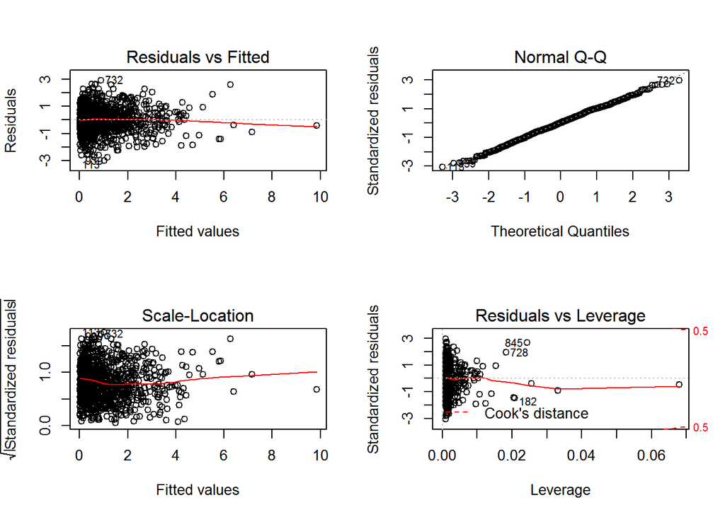

```r
model1<-lm(y~x, data=dane1)
par(mfrow=c(2,2))
plot(model1)
```

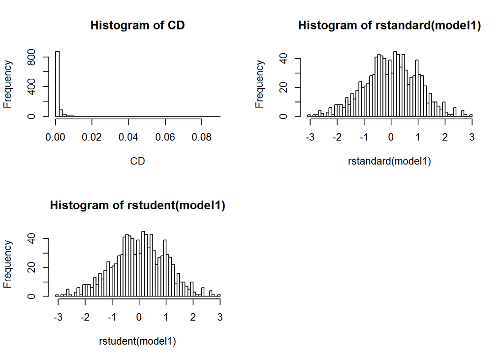

```r
CD=cooks.distance(model1)
hist(CD,breaks=50)
hist(rstandard(model1),breaks=50)
hist(rstudent(model1),breaks=50)
```

Widać, że wszystko się zgadza. Można dodatkowo sprawdzić rozkład normalny reszt testem Shapiro-Wilka

```r
shapiro.test(rstandard(model1))
```

```
##
##  Shapiro-Wilk normality test
##
## data:  rstandard(model1)
## W = 0.9981, p-value = 0.3228
```

pvalue jest wysokie, więc nie ma podstaw do odrzucenia hipotezy o normalności rozkładu reszt.

Generuję drugi zbiór danych:

```r
set.seed(18)
x2=rexp(1000)
y21=2*x2[1:500]+rnorm(500,0,1)
y22=17*x2[501:1000]+rnorm(500,0,1)
w=c(y21,y22)
dane2=data.frame(x2,w)
```

Zobaczmy jak wygląda na wykresach:

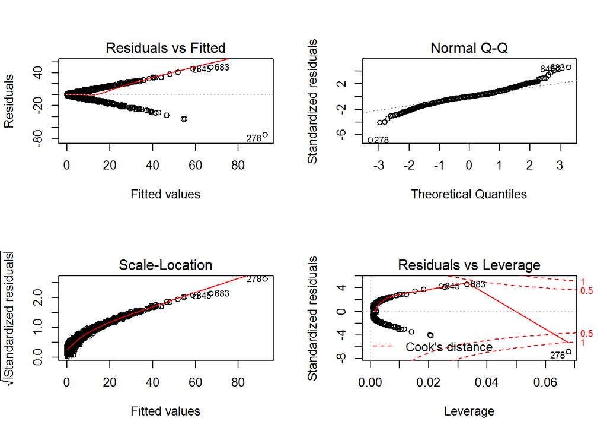

```r
model2<-lm(w~x2, data=dane2)
par(mfrow=c(2,2))
plot(model2)
```

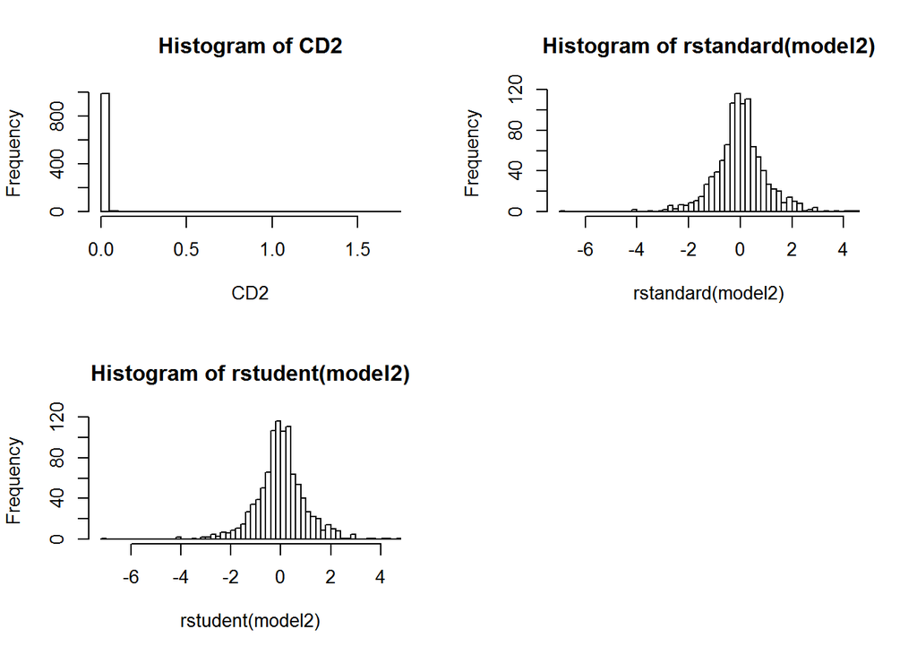

```r
CD2=cooks.distance(model2)
hist(CD2,breaks=50)
hist(rstandard(model2),breaks=50)
hist(rstudent(model2),breaks=50)
```

Widać, że teraz że model2 nie zgadza się na wykresach. Rozkład reszt nie jest normalny (na qqplocie ogony znacznie odstają, na histogramach widać, że ogony są za długie) ani nie ma homogeniczności wariancji.

### 3. Choose three tests for model diagnostic

- Breusch-Godfrey test for higher-order serial correlation.
- Breusch-Pagan test against heteroskedasticity
- Ramsey’s RESET test for functional form

### 4. For each test create two simulated datasets. One that passes the given test and one that does not

### 5. Present results from diagnostic tests, show p-values for both datasets.

Skorzystam z danych wygenerwoanych w punkcie 1.

- Breusch-Godfrey test

```r
library(lmtest)
bgtest(model1)
```

```
##
##  Breusch-Godfrey test for serial correlation of order up to 1
##
## data:  model1
## LM test = 0.1128, df = 1, p-value = 0.7369
```

```r
bgtest(model2)
```

```
##
##  Breusch-Godfrey test for serial correlation of order up to 1
##
## data:  model2
## LM test = 245.4704, df = 1, p-value < 2.2e-16
```

- Breusch-Pagan test

```r
bptest(model1)
```

```
##
##  studentized Breusch-Pagan test
##
## data:  model1
## BP = 1.3365, df = 1, p-value = 0.2477
```

```r
bptest(model2)
```

```
##
##  studentized Breusch-Pagan test
##
## data:  model2
## BP = 751.9977, df = 1, p-value < 2.2e-16
```

- Ramsey’s RESET test

```r
resettest(model1)
```

```
##
##  RESET test
##
## data:  model1
## RESET = 0.3724, df1 = 2, df2 = 996, p-value = 0.6892
```

```r
resettest(model2)
```

```
##
##  RESET test
##
## data:  model2
## RESET = 16.4065, df1 = 2, df2 = 996, p-value = 9.764e-08
```

Wszędzie model1 (dla dane1) ‘przechodzi’ test, a model2 (dla dane2) nie.